# Lab 08: The Wind Project Part II

### Stat R 301

### May 28, 2013

### Eli Gurarie

In this lab, along with covering some of the material from lecture, we will try to emulate an on-the-fly package building workflow, and hopefully illustrate some of the advantages. As we look at wind direction transition matrices, we will gradually build a package in R called `markovWind`.

You will need, at the least, to have the following packages installed and running:

```r
require(roxygen2)
require(igraph)
require(zoo)
```

### Markov Matrices

#### Obtaining a Markov Chain

Load the `WindDirections.robj` data file, either from your directory or directly off the internet:

```r
load("WindDirections.robj")
load(url("http://faculty.washington.edu/eliezg/StatR301/Lab08/WindDirections.robj"))
head(Theta)
```

```
##       B1     B2     B3
## 0 305.93  30.50 288.63
## 1 303.78  41.07 287.54
## 2 334.20 328.48 249.66
## 3  58.94  95.25  66.13
## 4   8.98 243.46  21.78
## 5  13.08 234.67  46.92
```

These contain the daily mean wind direction of the three of the weather buoys from last week(51000, 51002 and 51003).

**Question:** How did I obtain the mean daily wind direction from the raw data (in a few lines of code)?

We would like to “discretize” the wind directions (column `$Direction`) into N-E-S-W. To do that, we use the “cut” function, as illustrated below on a subset of the data:

```r
B1.mc <- cut(Theta$B1, c(0, 45 + 90 * 0:3, 360), c("N", "E", "S", "W", "N"))
```

```
## Warning: duplicated levels in factors are deprecated
```

Note there is a warning and a few minor problems with this slicing. Why? The following cleans up the whole setup:

```r
# collapse the two 'N' factors
B1.mc <- factor(as.character(B1.mc))
# Make 'N' the first in the ordering
B1.mc <- relevel(B1.mc, "N")
```

**Exercise 1:** Write a function calles `getNESW(Theta)` that obtains the discrete `nesw` series from wind direction data.

Okay, lets plot buoy 1:

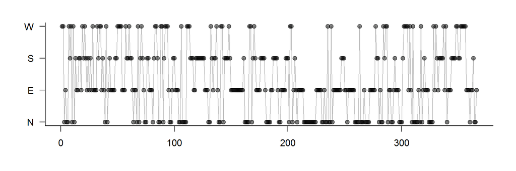

```r
plot(1:length(B1.mc), B1.mc, col = "grey", type = "l", ylab = "", yaxt = "n",
    xlab = "")
points(1:length(B1.mc), B1.mc, col = rgb(0, 0, 0, 0.5), pch = 19)
axis(2, 1:length(levels(B1.mc)), labels = levels(B1.mc), las = 1)
```

Again, this is a nice, useful method for plotting a markov chain, so lets create a function that does it:

```r
plot.mc <- function(mc, col = as.integer(mc), ...) {
    plot(1:length(mc), mc, col = "grey", type = "l", yaxt = "n", ...)
    points(1:length(mc), mc, col = col, pch = 19)
    axis(2, 1:length(levels(mc)), labels = levels(mc), las = 1)
}
```

Let's test this function:

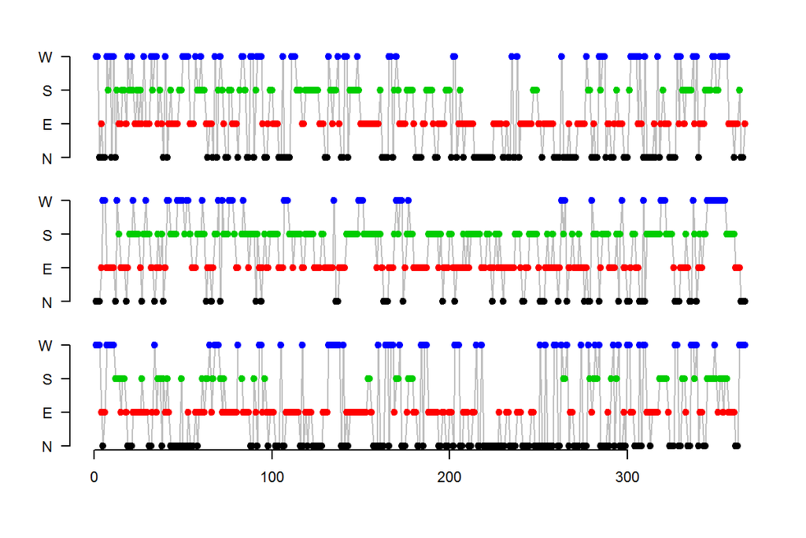

```r
plot.mc(getNESW(Theta$B1), axes = FALSE, xlab = "", ylab = "B1")
plot.mc(getNESW(Theta$B2), axes = FALSE, xlab = "", ylab = "B2")
plot.mc(getNESW(Theta$B3), axes = FALSE, xlab = "Time", ylab = "B3")
axis(1)
```

#### Estimating the transition matrix

There are (as far as I know) no existing functions that quickly obtain transition matrices from a markov chain. Thankfully, it is relatively simple thing to do. **Exercise:** Refrain from looking below, and think about how.

Here's a function:

```r
getM.mc <- function(mc) {
    M.count <- as.matrix(table(mc[-length(mc)], mc[-1]))
    M.count/rowSums(M.count)
}
(M1 <- getM.mc(B1.mc))
```

```
##
##           N       E       S       W
##   N 0.50515 0.22680 0.08247 0.18557
##   E 0.21488 0.55372 0.16529 0.06612
##   S 0.06173 0.28395 0.45679 0.19753
##   W 0.25758 0.15152 0.24242 0.34848
```

Let's get the transition matrix for the other two:

```r
M2 <- getM.mc(getNESW(Theta$B2))
M3 <- getM.mc(getNESW(Theta$B3))
```

Now, if we could graph the transition matrix:

```r
plot.mtm <- function(M, ...) {
    M.graph <- graph.adjacency(M, mode = "directed", weighted = TRUE)
    plot(M.graph, vertex.size = 40, edge.width = M[M > 0] * 10, edge.color = rgb(0,
        0, 0, 0.5), ...)
}
```

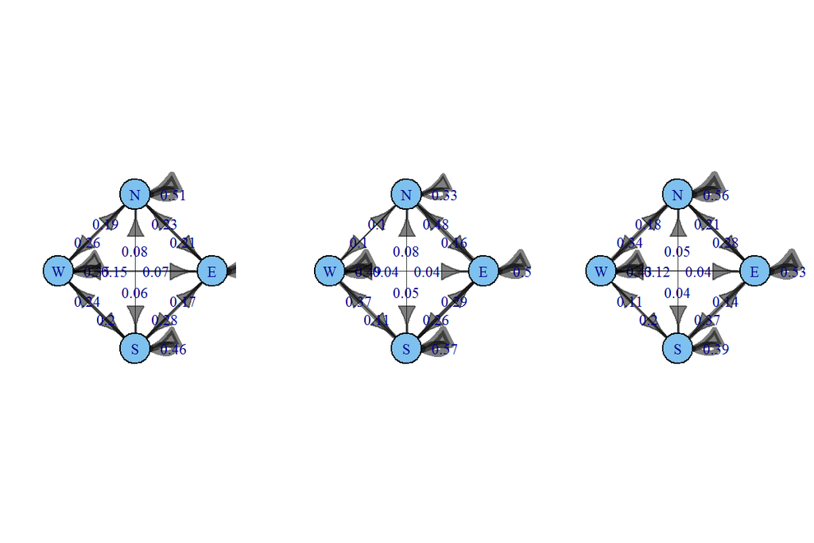

```r
layout <- cbind(c(0, 1, 0, -1), c(1, 0, -1, 0))
plot.mtm(M1, layout = layout, edge.label = round(M1, 2))
plot.mtm(M2, layout = layout, edge.label = round(M2, 2))
plot.mtm(M3, layout = layout, edge.label = round(M3, 2))
```

### Pause to make a package

Great - we now have a couple of functions that are useful to us, one dataset to analyze, and two new plot commands that are specific to types of data, thereby motivating use of a novel method.

The easiest way to build the outlines of a package is to create some of the key simple functions and load some datasets, and then run the `package.skeleton()` command in R. Then, we associate a “project” in Rstudio with the skeleton.  
So, here are the steps:

Clear your workspace and load just the data and functions you need to start things off:

```r
rm(list = ls())
load("WindDirections.robj")
getNESW <- function(Theta) {
    NESW <- cut(Theta, c(0, 45 + 90 * 0:3, 360), c("N", "E", "S", "W", "N"))
    NESW <- factor(as.character(NESW))
    NESW <- relevel(NESW, "N")
    NESW
}
plot.mc <- function(mc, col = as.integer(mc), ...) {
    plot(1:length(mc), mc, col = "grey", type = "l", yaxt = "n", ...)
    points(1:length(mc), mc, col = col, pch = 19)
    axis(2, 1:length(levels(mc)), labels = levels(mc), las = 1)
}
getM.mc <- function(mc) {
    M.count <- as.matrix(table(mc[-length(mc)], mc[-1]))
    M.count/rowSums(M.count)
}
plot.mtm <- function(M, ...) {
    M.graph <- graph.adjacency(M, mode = "directed", weighted = TRUE)
    plot(M.graph, vertex.size = 40, edge.width = M[M > 0] * 10, edge.color = rgb(0,
        0, 0, 0.5), ...)
}
```

Run the package skeleton command

```r
package.skeleton("mRkov", path = "c:\\eli\\Rstuff")
```

Within RStudio, go to “Project/Create Project”, enter “Existing Directory”, and find your project directory. RStudio will blank out, and re-open within your project world (which is where you want to be). Note the file menu contains all of the pieces of your new package.

Try building your package right now (“Build/Build and Reload” or `Ctrl-Shift-B`). It should fail, but should also give you a useful message:

```r
Error in Rd_info(db[[i]]) :
  missing/empty \title field in 'C:/eli/programming/mRkov/man/Theta.Rd'
```

This is a useful message, saying that a minimal piece of information is missing from some help files. Let's fill that in. Open the `Theta.Rd` file (I'm not sure that it is meaningful to “roxygenate” a data file - so we do this bit by hand) and, very minimally, simply fill out this line:

```r
\title{Wind directions from three buoys}
```

Try compiling again (don't be shy!). It will fail again, because it needs title fields for all of the functions as well. For the actual code files, we might as well Roxygenate them. So, for example, open `getM.mc.R` and add the following lines to the top of the file:

```r
##' Obtain Markov Transition matrix from markov chain
```

Try again. Still no luck? Here, you just have to tell RStudio to roxygenate while compiling. So, in “Build/Configure Build Tools” click on “Generate documentation with Roxygen”, click on “configure”, and click on “Build & Reload”. (Note, these options will only appear if you have the `roxygen2` package installed.)

Ok, now add a header title to the remaining 3 functions, and `Ctrl-Alt-B` again. There should be a couple of warnings, but then … IT WORKED! Congratulations - your first (or second) package, ultra-minimal though it may be.

### Dependencies

I personally like doing all my package development in RStudio and then actively working with it in a different instance of R (usually with my favorite Notepad++). Check out that this works by opening a new instance of R and entering these commands:

```r
require(mRkov)
ls("package:mRkov")
```

[output not shown]

And check out the (so far, not very helpful) help files.

The data is there:

```r
data(Theta)
```

but if you started a brand new instance of R (with none of the ancillary packages installed), then `plot(Theta)` will not give you what you expect (try it!).

Also:

```r
B1.mc <- getNESW(Theta[, 1])
B1.M <- getM.mc(B1.mc)
plot.mtm(B1.M)
```

will fail. This is all because the whole package “Depends” on functions in other packages, specifically: `zoo` and `igraph`.

Adding dependencies (i.e.~automoatically loading the required libraries) is a simple matter of adding the following line to the `DESCRIPTION` file:

```r
Depends: igraph, zoo
```

Add those lines, recompile, and (in your other session) reload `mRkov`. Note, that you'll have to “detach” the loaded library before you can load the newly compiled one. You do this via:

```r
detach("package:mRkov", unload = TRUE)
require(mRkov)
```

I do this so often when I am revising and rebuilding, that I often add a `refresh()` function to my package that simply runs those two lines of code.

### Defining a class

Ok, now for something new and powerful. R is an object oriented programming (OOP) style language in the sense that all objects in it are of a `class`, most in what is known as `S3`, some in the much stricter `S4` and some in the mysterious to me `R5`. I'll talk about these (a bit) in lecture, but the important thing to know is that once an object is associated with a *class*, then you can define a *method* for several *generic functions* that is specific to thie class. Technically, the identification of the class *dispatches* the generic function to a class-specific function call. The most important and familar examples are: `plot()`, `summary()`, `print()`, all of which behave somewhat differently depending on the type of object they are applied to.

We can create this specific type of functionality in our package relatively simply. We would like to define two kinds of objects: a “Markov chain” (mc) class, and a “Transition Matric” (mtm) class, each of which will have its own `plot()` methods. Here are the steps:

To specify a class, you just use the `class()` function:

```r
B1.mc <- getNESW(Theta[, 1])
class(B1.mc) <- "ms"
is(B1.mc)
```

```
## [1] "ms"
```

```r
attributes(B1.mc)
```

```
## $levels
## [1] "N" "E" "S" "W"
##
## $class
## [1] "ms"
```

```r
getM.mc <- function(mc) {
    M.count <- as.matrix(table(mc[-length(mc)], mc[-1]))
    M <- M.count/rowSums(M.count)
    class(M) <- "mtm"
    return(M)
}

getNESW <- function(Theta) {
    options(warn = -1)
    NESW <- cut(Theta, c(0, 45 + 90 * 0:3, 360), c("N", "E", "S", "W", "N"))
    NESW <- factor(as.character(NESW))
    NESW <- relevel(NESW, "N")
    class(NESW) <- "mc"
    return(NESW)
}
```

Edit these respective functions, and recompile the package.

The generic functions pass some variable (usually `x`), which determines the method. (See: `?plot`, `?plot.ts`, `?plot.table`). Also, enter the simple generic commands:

```r
plot
```

```
## function (x, y, ...)
## UseMethod("plot")
## <bytecode: 0x00000000082a45a0>
## <environment: namespace:graphics>
```

```r
print
```

```
## function (x, ...)
## UseMethod("print")
## <bytecode: 0x000000000847c438>
## <environment: namespace:base>
```

And, finally, the most important step: declaring this new method. This occurs within the `NAMESPACE` file, which we let know that we created a brand new S3 method for `plot` specific to these two new classes. Open `NAMESPACE` and add the following two lines:

```r
S3method(plot, mc)
```

[output not shown]

```r
S3method(plot, mtm)
```

[output not shown]

Now, we should be able to perform:

```r
reload()
```

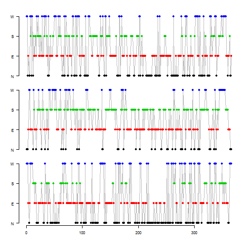

```r
data(Theta)
plot.mc(getNESW(Theta$B1), axes = FALSE, xlab = "", ylab = "B1")
plot.mc(getNESW(Theta$B2), axes = FALSE, xlab = "", ylab = "B2")
plot.mc(getNESW(Theta$B3), axes = FALSE, xlab = "Time", ylab = "B3")
axis(1)
```

and:

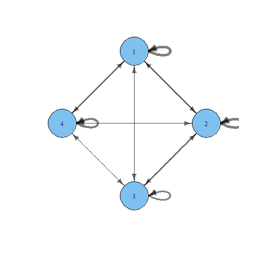

```r
plot(getM.mc(getNESW(Theta$B3)), layout = cbind(c(0, 1, 0, -1), c(1, 0, -1,
    0)))
```

We've programmed our first S3 methods! Congratulations.

### Simulating from transition matrix

To simulate a Markov chain from a matrix (following my lecture), you need only resample the next row with the appropriate probability distribution:

```r
simChain <- function(M, t) {
    n <- nrow(M)
    Xs <- rep(0, t)
    X <- sample(1:n, 1)
    Xs[1] <- X
    for (i in 2:t) {
        Xs[i] <- sample(1:n, 1, prob = M[Xs[i - 1], ])
    }
    Chain <- factor(row.names(M)[Xs])
    class(Chain) <- "mc"
    return(Chain)
}
```

[output not shown]

### Simulation based inference

Since we have all the pieces in place:

```r
reload()
```

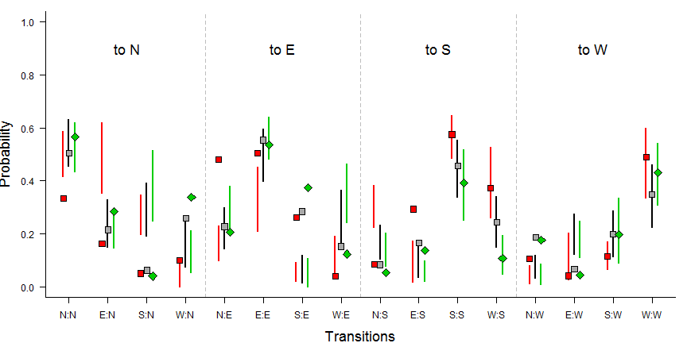

```r
data(Theta)
B1 <- getNESW(Theta[, 1])
B2 <- getNESW(Theta[, 2])
B3 <- getNESW(Theta[, 3])

M1 <- getM.mc(B1)
M2 <- getM.mc(B2)
M3 <- getM.mc(B3)

N <- 500
M1.sim <- array(0, dim = c(4, 4, N))
M2.sim <- array(0, dim = c(4, 4, N))
M3.sim <- array(0, dim = c(4, 4, N))

for (i in 1:N) {
    M1.sim[, , i] <- getM.mc(simChain(M1, 365))
    M2.sim[, , i] <- getM.mc(simChain(M2, 365))
    M3.sim[, , i] <- getM.mc(simChain(M3, 365))
}

M1.low <- apply(M1.sim, c(1, 2), quantile, 0.025)
M1.high <- apply(M1.sim, c(1, 2), quantile, 0.975)
M2.low <- apply(M2.sim, c(1, 2), quantile, 0.025)
M2.high <- apply(M2.sim, c(1, 2), quantile, 0.975)
M3.low <- apply(M3.sim, c(1, 2), quantile, 0.025)
M3.high <- apply(M3.sim, c(1, 2), quantile, 0.975)

labels <- outer(row.names(M1), row.names(M1), paste, sep = ":")

plot(1:16, as.vector(M1), ylim = c(0, 1), xaxt = "n", bty = "l", type = "n",
    ylab = "Probability", xlab = "Transitions")

segments(1:16, as.vector(M1.low), 1:16, as.vector(M1.high), lwd = 2)
segments(1:16 - 0.15, as.vector(M2.low), 1:16 - 0.15, as.vector(M2.high), lwd = 2,
    col = 2)
segments(1:16 + 0.15, as.vector(M3.low), 1:16 + 0.15, as.vector(M3.high), lwd = 2,
    col = 3)

points(1:16, as.vector(M1), bg = "darkgrey", pch = 22, cex = 1.5)
points(1:16 - 0.15, as.vector(M2), bg = 2, pch = 22, cex = 1.5)
points(1:16 + 0.15, as.vector(M3), bg = 3, pch = 23, cex = 1.5)

abline(v = 1:3 * 4 + 0.5, lty = 2, xpd = FALSE, col = "grey")
text(1:4 * 4 - 1.5, 0.9, labels = paste("to", levels(B1)), cex = 1.5)
axis(1, at = 1:16, label = labels)
```

The average resimulation C.I.~is about 0.17, or an approximate s.d. of 0.0415. These results suggest that there is a fair amount of similarity among the matrices, but note all the CI's that don't overlap with the actual estimates! Note especially the S to E and the S to N transitions. This suggests strongly that the first order Markov model is not the best model for many of these transitions (or that there's an error in my code!)

#### Final comments

It surprised me, personally, in preparing this lab that there aren't more straightforawrd tools for obtaining, estimating visualizing and analyzing Markov chains. Markov chains can be complex, and their analysis non-trivial, but we have estimated much more complicated ones (e.g. the HMM's of the last lecture). There actually seems to be a good opening here for a decent Markov Chain analysis toolkit that allows for some inference as well.

### Appendix

A likelihood based method for performing a test of a chain $B$ corresponding to a transition matrix $A$ is very succinctly summarized below (from this forum post: http://math.stackexchange.com/questions/86331/how-can-i-compare-two-matrices):

> In other words, you want to know whether the process that you observed and which gave rise to $B$ could correspond to a path of the Markov chain with transition matrix $A$, or not. A canonical way to answer this question is to compute the likelihood of the sequence of observations described by $B$ with respect to the model $A$. For Markov chains, this is
> $$L=\prod_{x,y}A(x,y)^{N(x,y)},$$
> where the product is over every states $x$ and $y$ and $N(x,y)$ is the number of times one observed a transition from $x$ to $y$. Presumably, $B$ corresponds to $B(x,y)=N(x,y)/N(x)$, where $N(x)$ is the number of times one observed a visit to $x$.

> If indeed the observed sequence was generated by the model $A$, $N(x,y)=nm(x)A(x,y)+o(n)$ for every $x$ and $y$, where $n$ is the length of the sequene and $m$ is the so-called stationary distribution of the Markov chain. Hence,

> $$\log L_A=n\cdot\Lambda_A+o(n),\quad \Lambda_A= \sum_{x,y}m(x)A(x,y)\log A(x,y).$$
> Furthermore, the discrepancy between $B$ and $A$ under the hypothesis that the sequence was generated by $A$ is described by a central limit theorem, that is, for every $x$ and $y$,
> $$N(x,y)=nm(x)A(x,y)+\sqrt{n}Z_{x,y}+o(\sqrt{n}),$$
> for a given centered gaussian family $(Z_{x,y})$ whose covariance matrix depends on $A$ and can be computed explicitly. Hence the approximate $p$-value of the observed sequence is
> $$\mathrm P(Z\approx (N-nm\cdot A)/\sqrt{n}).$$
> Assuming the covariance matrix of $Z$ is $C$, one gets an approximate $p$-value of $\mathrm e^{-K/2n}$, with
> $$K=(N-nm\cdot A)^*C^{-1}(N-nm\cdot A).$$
> One can also consider the likelihood $L$ and note that
> $$L=L_A^n\cdot L_{B\mid A},\qquad L_{B\mid A}=\prod_{x,y}A(x,y)^{N(x,y)-nm(x)A(x,y)},$$
> and use $L_{B\mid A}$ to estimate the discrepancy between the observed sequence, described by $(N(x,y))$, and the model, described by $A$.

Author of post: [Did](http://math.stackexchange.com/users/6179/did)